# IODS course project

# Open data science, Fall 2018

This is the first chapter of the Introduction to Open Datascience course. For now we are just learning RMarkdown and Github.

Project homepage is: https://github.com/suvivainio/IODS-project

# Regression and model validation

## Description of the dataset

My dataset for this exercise has 7 variables, gender is factor, age, attitude and points are integers and variables deep, stra and surf are double.

```
## 'data.frame':    166 obs. of  7 variables:
##  $ gender  : Factor w/ 2 levels "F","M": 1 2 1 2 2 1 2 1 2 1 ...
##  $ age     : int  53 55 49 53 49 38 50 37 37 42 ...
##  $ attitude: int  37 31 25 35 37 38 35 29 38 21 ...
##  $ points  : int  25 12 24 10 22 21 21 31 24 26 ...
##  $ deep    : num  3.58 2.92 3.5 3.5 3.67 ...
##  $ stra    : num  3.38 2.75 3.62 3.12 3.62 ...
##  $ surf    : num  2.58 3.17 2.25 2.25 2.83 ...
## NULL
```

First rows of the dataset look like this:

```
##   gender age attitude points     deep  stra     surf
## 1      F  53       37     25 3.583333 3.375 2.583333
## 2      M  55       31     12 2.916667 2.750 3.166667
## 3      F  49       25     24 3.500000 3.625 2.250000
## 4      M  53       35     10 3.500000 3.125 2.250000
## 5      M  49       37     22 3.666667 3.625 2.833333
## 6      F  38       38     21 4.750000 3.625 2.416667
```

Minimum and maximum values and some other descrptive numbers of the distribution:

```
##  gender       age           attitude         points           deep
##  F:110   Min.   :17.00   Min.   :14.00   Min.   : 7.00   Min.   :1.583
##  M: 56   1st Qu.:21.00   1st Qu.:26.00   1st Qu.:19.00   1st Qu.:3.333
##          Median :22.00   Median :32.00   Median :23.00   Median :3.667
##          Mean   :25.51   Mean   :31.43   Mean   :22.72   Mean   :3.680
##          3rd Qu.:27.00   3rd Qu.:37.00   3rd Qu.:27.75   3rd Qu.:4.083
##          Max.   :55.00   Max.   :50.00   Max.   :33.00   Max.   :4.917
##       stra            surf
##  Min.   :1.250   Min.   :1.583
##  1st Qu.:2.625   1st Qu.:2.417
##  Median :3.188   Median :2.833
##  Mean   :3.121   Mean   :2.787
##  3rd Qu.:3.625   3rd Qu.:3.167
##  Max.   :5.000   Max.   :4.333
```

## Variable selection

Below is a visual summary of the relationships in the data. Dependent variable for the linear model is going to be points.

Based on correlation and scatterplots variable Attitude seems a good candidate for an explanatory variable (correlation: 0.4).

As the two other variables for this regression I choose gender and age: it seems that the sign of regression terms might be different for men and women. This I want to investigate further.

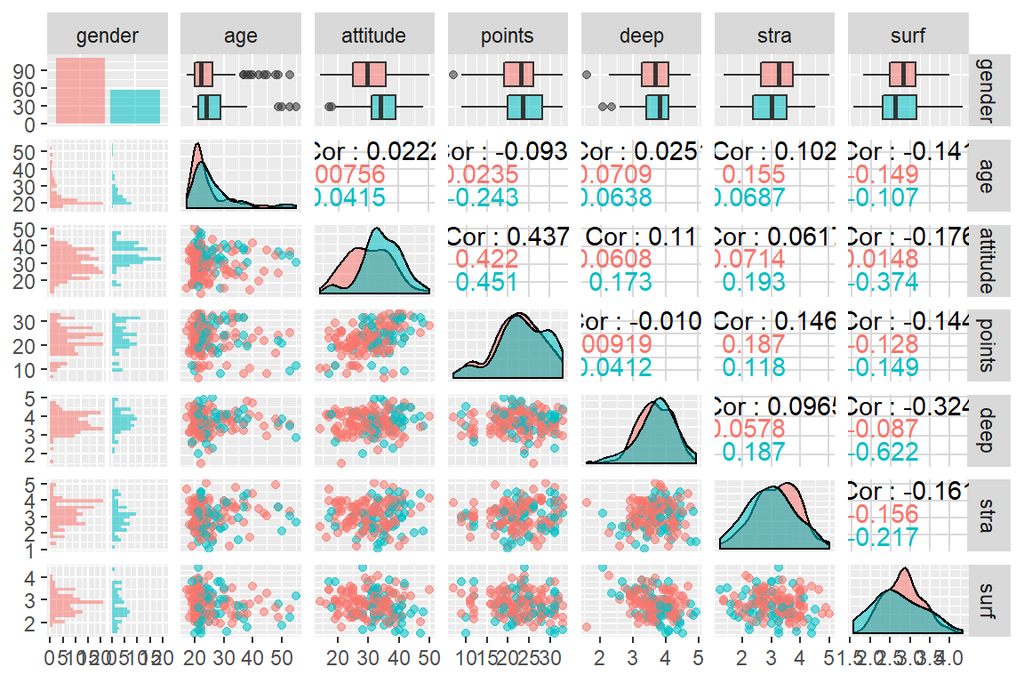

## Analysis

The only strong correlation that the visual plot matrix above was between points and attitude. It is no surprise that this relationship is statistically significant in the linear model as well (beta:Attitude=0.36066, p < 0.001). Variables gender and age proved to be non-significant in the model.

I also tried separate models for the two genders (not shown here) but age remained insignificant.

```
##
## Call:
## lm(formula = learning2014$points ~ learning2014$attitude + learning2014$age +
##     learning2014$gender)
##
## Residuals:
##      Min       1Q   Median       3Q      Max
## -17.4590  -3.3221   0.2186   4.0247  10.4632
##
## Coefficients:
##                       Estimate Std. Error t value Pr(>|t|)
## (Intercept)           13.42910    2.29043   5.863 2.48e-08 ***
## learning2014$attitude  0.36066    0.05932   6.080 8.34e-09 ***
## learning2014$age      -0.07586    0.05367  -1.414    0.159
## learning2014$genderM  -0.33054    0.91934  -0.360    0.720
## ---
## Signif. codes:  0 '***' 0.001 '**' 0.01 '*' 0.05 '.' 0.1 ' ' 1
##
## Residual standard error: 5.315 on 162 degrees of freedom
## Multiple R-squared:  0.2018, Adjusted R-squared:  0.187
## F-statistic: 13.65 on 3 and 162 DF,  p-value: 5.536e-08
```

Here is the linear model with the only statistically significant parameter attitude. Attitude is positively related to points variable. The final equation is:

points = 11.64 + attitude * 0.35

R-square statistic for this model is 0.1856, in other words attitude alone explains almost 20 % of the variation in points. This is quite a high pecentage! Below there’s a visualization of the model

```
##
## Call:
## lm(formula = learning2014$points ~ learning2014$attitude)
##
## Residuals:
##      Min       1Q   Median       3Q      Max
## -16.9763  -3.2119   0.4339   4.1534  10.6645
##
## Coefficients:
##                       Estimate Std. Error t value Pr(>|t|)
## (Intercept)           11.63715    1.83035   6.358 1.95e-09 ***
## learning2014$attitude  0.35255    0.05674   6.214 4.12e-09 ***
## ---
## Signif. codes:  0 '***' 0.001 '**' 0.01 '*' 0.05 '.' 0.1 ' ' 1
##
## Residual standard error: 5.32 on 164 degrees of freedom
## Multiple R-squared:  0.1906, Adjusted R-squared:  0.1856
## F-statistic: 38.61 on 1 and 164 DF,  p-value: 4.119e-09
```

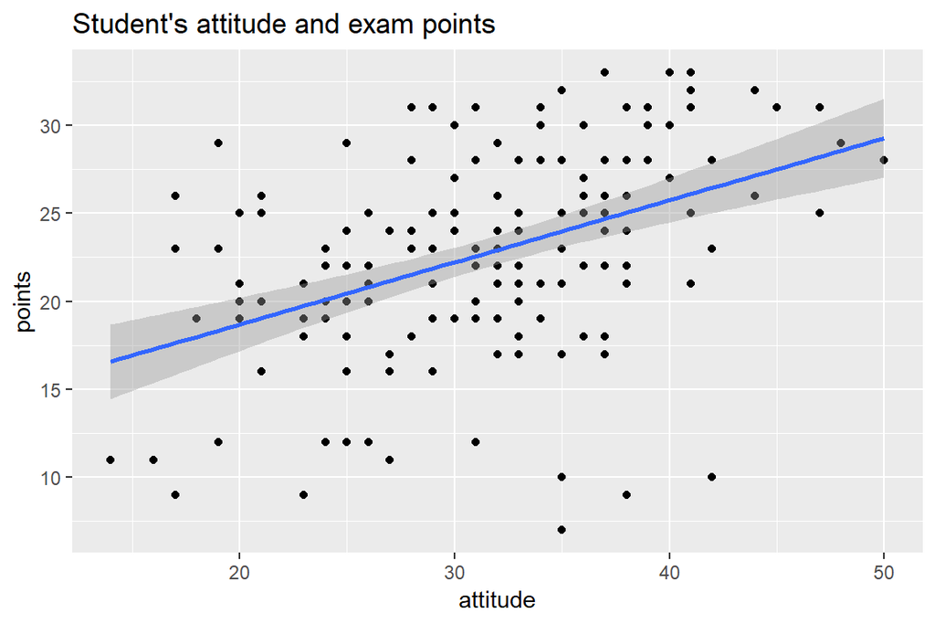

## Diagnostic of the model

In the normal model the basic equation is:

y = a + bx + error

Errors are supposed to be independent of y (here: attitude) and follow normal distribution.

Residuals vs. fitted values plot (below) shows that there exists no correlation or other kind of clear dependence between y values and error values.

Q-Q-plot shows that the standardized residuals approximately follow normal distribution. This means that the assumption of normality can be considered fulfilled.

The residuals versus leverage plot is used to inspect the effect of the observations to the model. Scatter plot of the data and fitted regression line (plot above) has no notable outliers and the leverage plot tells the same story: there are no especially high leverage values.

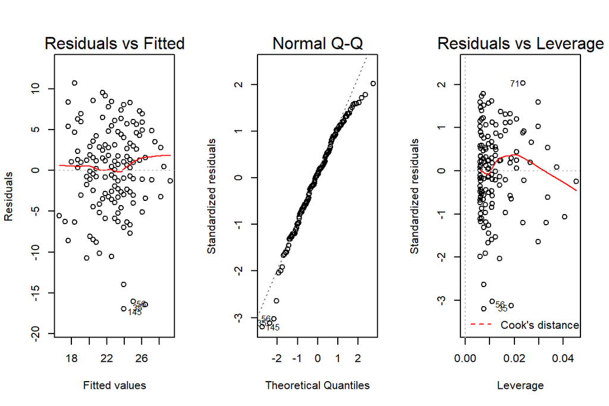

All in all, after examining the diagnostics’ plots it can be concluded that the model is valid.

# Logistic regression

This week’s exercise is to examine the relationships between high/low alcohol consumption and other variables of the data

The dataset is courtecy of:

P. Cortez and A. Silva. Using Data Mining to Predict Secondary School Student Performance. In A. Brito and J. Teixeira Eds., Proceedings of 5th FUture BUsiness TEChnology Conference (FUBUTEC 2008) pp. 5-12, Porto, Portugal, April, 2008, EUROSIS, ISBN 978-9077381-39-7.

For exact information about the contents of the variables see: https://archive.ics.uci.edu/ml/datasets/Student+Performance

The datasets is originally about student achivement in secondary education of two Portuguese schools. Dataset includes variables such as grades, demographic, social and school-related features.

There are two datasets downloadable from the homepage, one regarding the performance in mathematics the other regarding the performance in Portuguese. For the purposes of this exercise the data sets were combined into one dataset. Calculated variables about alcohol use were added: - alc_use, average of self-assessed alcohol-use during workdays and weekends, 1 very low and 5 very high - boolean variable high use: high_use: true, if alc_use > 2

## Choosing variables for the analysis

There are plenty of hypotheses that could be tested with this data. Are students who spend a lot of time studying so busy that they don’t have the time to drink? Or maybe kids from large families sneak out to drink while their parents are busy looking after the other ciblings?

Before choosing the variables I want to see, that there is enough variation so that the analysis is meaningful.

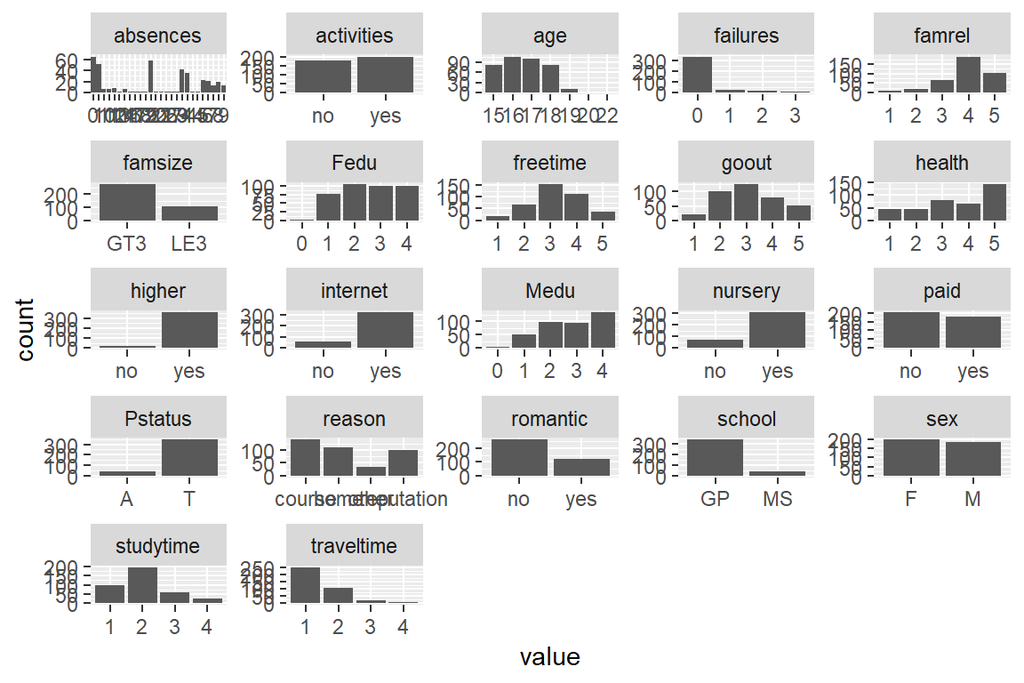

Based on the plots above I choose to examine the alcohol consumption’s relationship to the pro-education characteristics of the pupil and his or her parents. The variables I choose for further analysis are:

- mother’s education (0: none, 1: primary education, 2: 5th to 9th grade, 3: secondary education, 4: higher education)
- father’s education (same as above)
- study time (1: <2 hrs, 2: 2-5 hrs, 3: 5-10 hrs, 4: >10 hrs)
- reason to choose a certain school (close to home, school reputation, course preference, other)

Hypotheses are as follows: The higher the education of the parents the more emphasis they lay for school work and thus their kids drink less. The more time the pupil spends studying the more important it is for him or her to be succesfull at school and that is why they drink less. Finally, if the motivation for the choice of school is school reputation or course preference then I assume that school work is also considered important, and these youngsters would drinks less.

The variable study time does not need to be recoded. However, before the analysis I want to recode the reason to choose a certain school into two categories: 1 choice of school was made on academic grounds and 2 choice of school was made on other grounds. Furthermore I there are only couple of observations in the category “none” for parents’ education, so I combine the observations in the categories “none” and “primary education” into same category.

## Description of the analysis variables

Below are the summaries of the analysis variables.

In the data set 30 % of the observations belong to the group where alcohol consumption is high.

```
## [1] "Alchol use is high (dependent variable): "
```

```
##
##     FALSE      TRUE
## 0.7015707 0.2984293
```

```
## [1] "Reason the choose this school: "
```

```
##
##          academic     other
##   FALSE 0.3358209 0.6641791
##   TRUE  0.4736842 0.5263158
```

```
## [1] "Mother's education: "
```

```
## [1] "1 none or primary education (4th grade), 2 5th to 9th grade, 3 secondary education or 4 higher education"
```

```
##
##                 1         2         3         4
##   FALSE 0.1268657 0.2985075 0.2201493 0.3544776
##   TRUE  0.1754386 0.1578947 0.3157895 0.3508772
```

```
## [1] "Father's education: "
```

```
##
##                 1         2         3         4
##   FALSE 0.2052239 0.2798507 0.2686567 0.2462687
##   TRUE  0.2105263 0.2631579 0.2368421 0.2894737
```

```
## [1] "Time spent studying:  "
```

```
## [1] "1 - <2 hours, 2 - 2 to 5 hours, 3 - 5 to 10 hours, or 4 - >10 hours"
```

```
##
##                  1          2          3          4
##   FALSE 0.21641791 0.50373134 0.19402985 0.08582090
##   TRUE  0.36842105 0.52631579 0.07017544 0.03508772
```

## Analysis

Analysis confirms the doubts that propensity tables hinted to: mother’s and father’s education doesn’t have a statistically significant relationship with high alchol consumption.

The only hypothesis that gains support is that the students who spent more time studying have less often high alcohol consumption.

```r
model=glm(high_use ~ Medu+Fedu+reason2cat+studytime ,data = alc)
print(summary(model))
```

```
##
## Call:
## glm(formula = high_use ~ Medu + Fedu + reason2cat + studytime,
##     data = alc)
##
## Deviance Residuals:
##     Min       1Q   Median       3Q      Max
## -0.4865  -0.3470  -0.2473   0.5539   0.9566
##
## Coefficients:
##                  Estimate Std. Error t value Pr(>|t|)
## (Intercept)      0.537229   0.088520   6.069 3.14e-09 ***
## Medu             0.010198   0.028585   0.357 0.721468
## Fedu             0.003559   0.028101   0.127 0.899290
## reason2catother -0.098188   0.047755  -2.056 0.040460 *
## studytime       -0.105797   0.027720  -3.817 0.000158 ***
## ---
## Signif. codes:  0 '***' 0.001 '**' 0.01 '*' 0.05 '.' 0.1 ' ' 1
##
## (Dispersion parameter for gaussian family taken to be 0.200682)
##
##     Null deviance: 79.979  on 381  degrees of freedom
## Residual deviance: 75.657  on 377  degrees of freedom
## AIC: 477.53
##
## Number of Fisher Scoring iterations: 2
```

```r
print("Odds ratios and their confidence intervals")
```

```
## [1] "Odds ratios and their confidence intervals"
```

```r
odds=cbind(coef(model)%>%exp, confint(model)%>%exp)
print(odds)
```

```
##                               2.5 %    97.5 %
## (Intercept)     1.7112583 1.4386908 2.0354653
## Medu            1.0102503 0.9552065 1.0684661
## Fedu            1.0035651 0.9497865 1.0603888
## reason2catother 0.9064782 0.8254840 0.9954194
## studytime       0.8996069 0.8520354 0.9498344
```

Only studytime and reason the choose the current school were statistically significant in the first model. But since the confidence interval of the reason variable almost includes 1 (upper CL=0.9954194), only study time variable is kept in the final model.

```r
model=glm(high_use ~ studytime ,data = alc)
print(summary(model))
```

```
##
## Call:
## glm(formula = high_use ~ studytime, data = alc)
##
## Deviance Residuals:
##     Min       1Q   Median       3Q      Max
## -0.4154  -0.3026  -0.3026   0.5846   0.9231
##
## Coefficients:
##             Estimate Std. Error t value Pr(>|t|)
## (Intercept)  0.52821    0.06043    8.74  < 2e-16 ***
## studytime   -0.11282    0.02745   -4.11 4.84e-05 ***
## ---
## Signif. codes:  0 '***' 0.001 '**' 0.01 '*' 0.05 '.' 0.1 ' ' 1
##
## (Dispersion parameter for gaussian family taken to be 0.2015115)
##
##     Null deviance: 79.979  on 381  degrees of freedom
## Residual deviance: 76.574  on 380  degrees of freedom
## AIC: 476.13
##
## Number of Fisher Scoring iterations: 2
```

```r
print("Odds ratios and their confidence intervals")
```

```
## [1] "Odds ratios and their confidence intervals"
```

```r
odds=cbind(coef(model)%>%exp, confint(model)%>%exp)
print(odds)
```

```
##                          2.5 %    97.5 %
## (Intercept) 1.695886 1.5064487 1.9091445
## studytime   0.893311 0.8465245 0.9426833
```

## Predictive power of model

As could be expected the model turned out to be suboptimal also in terms of predictive power. Only low alcohol consumption was predicted, not a single observation was predicted to the high alchol consumption category. This means that 30 % of the observations were misclassified (that is all of students that reported high alcohol consumption).

```r
probabilities <- predict(model, type = "response")
alc <- mutate(alc, probability = probabilities)
alc <- mutate(alc, prediction = probabilities > 0.5)
table(high_use = alc$high_use, prediction = alc$prediction)
```

```
##         prediction
## high_use FALSE
##    FALSE   268
##    TRUE    114
```

Some rows with depent variable and independent variable and the prediction:

```r
select(alc, studytime, high_use, probability, prediction) %>% tail(10)
```

```
##     studytime high_use probability prediction
## 373         1     TRUE   0.4153846      FALSE
## 374         1     TRUE   0.4153846      FALSE
## 375         1     TRUE   0.4153846      FALSE
## 376         2     TRUE   0.3025641      FALSE
## 377         1    FALSE   0.4153846      FALSE
## 378         1     TRUE   0.4153846      FALSE
## 379         3    FALSE   0.1897436      FALSE
## 380         1     TRUE   0.4153846      FALSE
## 381         2     TRUE   0.3025641      FALSE
## 382         1    FALSE   0.4153846      FALSE
```

```r
library(Rlab)
set.seed(40)
alc$bernoulliPred=rbern(dim(alc)[1], 0.3)
table(high_use = alc$high_use, Bernoulli = alc$bernoulliPred)%>%prop.table()
```

```
##         Bernoulli
## high_use          0          1
##    FALSE 0.50523560 0.19633508
##    TRUE  0.20418848 0.09424084
```

# Dimensionality reduction techniques

The data for this week’s exercise is the UN human development index data that was manipulated by the course assistants.

Long names for the variables can be found in: https://raw.githubusercontent.com/TuomoNieminen/Helsinki-Open-Data-Science/master/datasets/human_meta.txt

The data has a couple of linear relationships (for example between life-expectancy and expected years of schooling, or the women to men ratio in secondary education). There is also relationships that look more polynomial than linear in nature, for example maternal mortality ratio seems to have a ‘curvy’ relationship with many of the other variables, e.g. life-expectancy or expected years in schooling.

There exist also large correlations in the data set (>0.5), which indicates that variables might be describing an underlying and unobserved dimension and thus dimensionality reduction makes sense here.

I’m not quite happy for having some small countries that are very rich - have especially high GNI - by mere coincidence than having had progressive and innovative environment for their businesses. Thus I’ll take the liberty of excluding Qatar from the analysis, since it is such an anomaly for a country. In terms of population you could also think about deleting some of next rich but very small countries, but I’ll let them be.

```
## 'data.frame':    154 obs. of  8 variables:
##  $ Edu2.FM  : num  1.007 0.997 0.983 0.989 0.969 ...
##  $ Labo.FM  : num  0.891 0.819 0.825 0.884 0.829 ...
##  $ Edu.Exp  : num  17.5 20.2 15.8 18.7 17.9 16.5 18.6 16.5 15.9 19.2 ...
##  $ Life.Exp : num  81.6 82.4 83 80.2 81.6 80.9 80.9 79.1 82 81.8 ...
##  $ GNI      : num  64992 42261 56431 44025 45435 ...
##  $ Mat.Mor  : int  4 6 6 5 6 7 9 28 11 8 ...
##  $ Ado.Birth: num  7.8 12.1 1.9 5.1 6.2 3.8 8.2 31 14.5 25.3 ...
##  $ Parli.F  : num  39.6 30.5 28.5 38 36.9 36.9 19.9 19.4 28.2 31.4 ...
```

```
##     Edu2.FM          Labo.FM          Edu.Exp         Life.Exp
##  Min.   :0.1717   Min.   :0.1857   Min.   : 5.40   Min.   :49.00
##  1st Qu.:0.7427   1st Qu.:0.5981   1st Qu.:11.30   1st Qu.:66.42
##  Median :0.9402   Median :0.7529   Median :13.50   Median :74.20
##  Mean   :0.8559   Mean   :0.7065   Mean   :13.21   Mean   :71.79
##  3rd Qu.:0.9968   3rd Qu.:0.8531   3rd Qu.:15.20   3rd Qu.:77.28
##  Max.   :1.4967   Max.   :1.0380   Max.   :20.20   Max.   :83.50
##       GNI            Mat.Mor          Ado.Birth         Parli.F
##  Min.   :   680   Min.   :   1.00   Min.   :  0.60   Min.   : 0.00
##  1st Qu.:  4495   1st Qu.:  11.25   1st Qu.: 12.62   1st Qu.:12.40
##  Median : 12081   Median :  49.00   Median : 33.20   Median :19.35
##  Mean   : 17739   Mean   : 144.34   Mean   : 46.83   Mean   :20.97
##  3rd Qu.: 24518   3rd Qu.: 190.00   3rd Qu.: 71.78   3rd Qu.:28.07
##  Max.   :123124   Max.   :1100.00   Max.   :204.80   Max.   :57.50
```

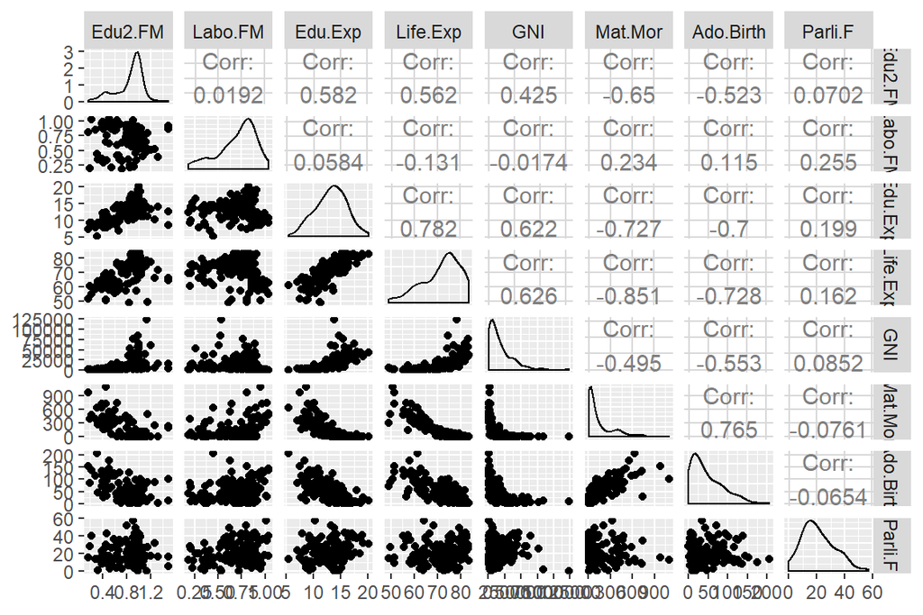

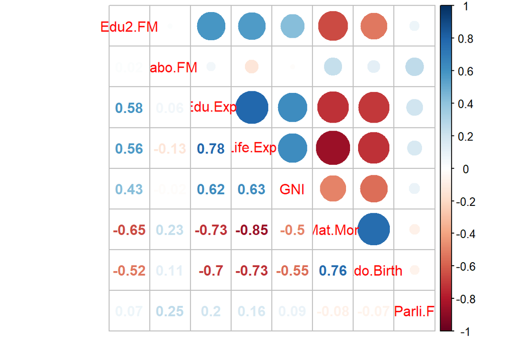

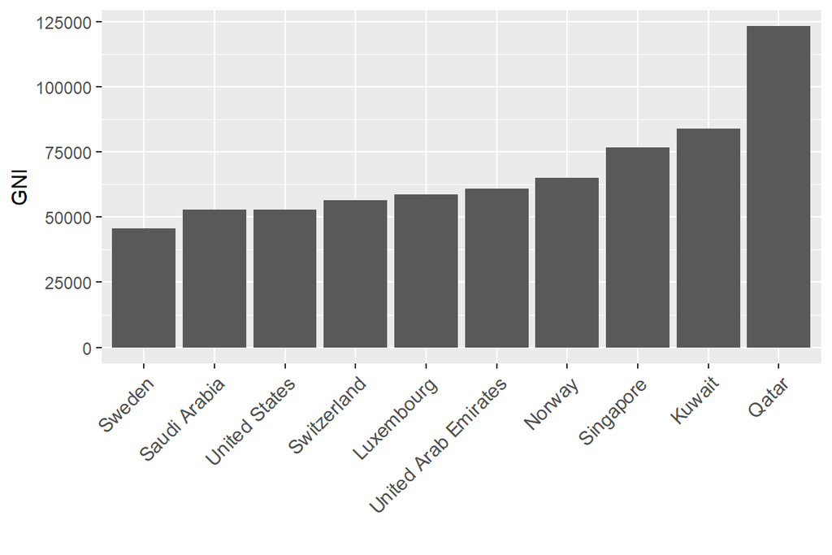

## Principal component analysis

The first principal component analysis is performed on the non-standardized dataset. PCA is sensitive to scales and variances and in the data set the ranges vary a lot.

Indeed the unstandardized principle component analysis manages to differentiate between countries that are materially very well of (like Kuwait, Singapore, Norway and the USA). In this case using just GNI is simpler and this complex analysis does not add a lot of value. First component captures 100 % of the variance.

```
## Standard deviations (1, .., p=8):
## [1] 1.652100e+04 1.747522e+02 2.479978e+01 1.124852e+01 3.699487e+00
## [6] 1.537905e+00 1.924201e-01 1.599784e-01
##
## Rotation (n x k) = (8 x 8):
##                     PC1           PC2           PC3           PC4
## Edu2.FM   -6.259677e-06 -0.0006771787 -6.614863e-05 -0.0002971124
## Labo.FM   -2.088355e-07  0.0003213676  4.296033e-04 -0.0044154107
## Edu.Exp   -1.181029e-04 -0.0068810560  1.170346e-02 -0.0242860527
## Life.Exp  -3.343840e-04 -0.0273215059  7.367941e-03 -0.0516563085
## GNI       -9.999773e-01  0.0067035584 -6.051895e-04  0.0001453210
## Mat.Mor    6.563577e-03  0.9913459128  1.283503e-01 -0.0033435764
## Ado.Birth  1.458569e-03  0.1280374997 -9.914452e-01  0.0182831078
## Parli.F   -1.206711e-04  0.0006055789 -1.925756e-02 -0.9981867344
##                     PC5           PC6           PC7           PC8
## Edu2.FM    0.0025163127  2.266647e-02  6.981981e-01  7.155409e-01
## Labo.FM   -0.0014878017  3.255761e-02  7.148261e-01 -6.985282e-01
## Edu.Exp   -0.1199162919  9.916099e-01 -3.883569e-02  6.888979e-03
## Life.Exp  -0.9908655860 -1.211774e-01  5.250124e-03  2.153616e-03
## GNI        0.0001459492 -4.424775e-05 -6.153145e-07 -9.106189e-07
## Mat.Mor   -0.0264604220  2.082721e-03  1.331727e-04  8.458637e-04
## Ado.Birth -0.0132553771  1.143293e-02 -8.660072e-05 -1.939263e-04
## Parli.F    0.0540467186 -1.780343e-02 -2.698653e-03  2.591464e-03
```

```
## Importance of components:
##                              PC1       PC2  PC3   PC4   PC5   PC6    PC7
## Standard deviation     1.652e+04 174.75221 24.8 11.25 3.699 1.538 0.1924
## Proportion of Variance 9.999e-01   0.00011  0.0  0.00 0.000 0.000 0.0000
## Cumulative Proportion  9.999e-01   1.00000  1.0  1.00 1.000 1.000 1.0000
##                         PC8
## Standard deviation     0.16
## Proportion of Variance 0.00
## Cumulative Proportion  1.00
```

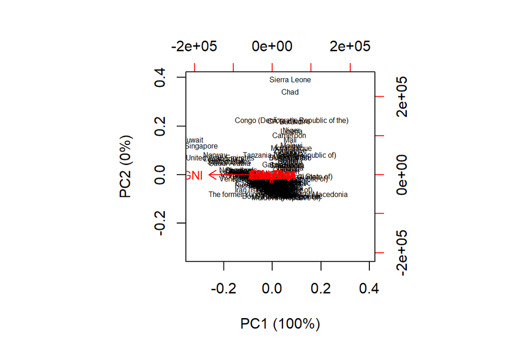

The second analysis is performed on the standardized dataset. This time there are 2 components, that capture 70 % of the variation, with first componen accounting 54 %.

Second component consists of female to male ratio in the labour force (0.72) and percentage of female representatives in parliament (0.64). This dimension describes the equality of men and women in relation to power.

```
## Standard deviations (1, .., p=8):
## [1] 2.0796591 1.1446342 0.8731711 0.7724212 0.6388233 0.5312363 0.4584886
## [8] 0.3244212
##
## Rotation (n x k) = (8 x 8):
##                   PC1         PC2         PC3         PC4         PC5
## Edu2.FM   -0.34780421  0.02201214 -0.33522080  0.69089531 -0.47573796
## Labo.FM    0.04099046  0.72355978 -0.58847217 -0.06167349  0.27067548
## Edu.Exp   -0.42776539  0.12287124 -0.08281142 -0.14787124  0.03857275
## Life.Exp  -0.44080871 -0.04340355  0.10505186 -0.08019736  0.12902296
## GNI       -0.36968433  0.12113853 -0.00901504 -0.60982622 -0.58939866
## Mat.Mor    0.43251606  0.17844542 -0.06052981 -0.23069612 -0.25999380
## Ado.Birth  0.40898841  0.09640031  0.02395493  0.10012510 -0.51630720
## Parli.F   -0.09512255  0.63496864  0.72049631  0.23543315 -0.02669666
##                   PC6         PC7         PC8
## Edu2.FM    0.19541963 -0.00974105 -0.15565360
## Labo.FM   -0.07188544  0.20185351  0.07416433
## Edu.Exp   -0.32798388 -0.81477700  0.01652132
## Life.Exp  -0.47103010  0.41201166 -0.61487106
## GNI        0.20439101  0.21782718  0.20018620
## Mat.Mor    0.23806413 -0.27496691 -0.72410250
## Ado.Birth -0.71883810  0.04747939  0.16516948
## Parli.F    0.10964692 -0.01534082  0.01588502
```

```
## Importance of components:
##                           PC1    PC2    PC3     PC4     PC5     PC6
## Standard deviation     2.0797 1.1446 0.8732 0.77242 0.63882 0.53124
## Proportion of Variance 0.5406 0.1638 0.0953 0.07458 0.05101 0.03528
## Cumulative Proportion  0.5406 0.7044 0.7997 0.87428 0.92529 0.96057
##                            PC7     PC8
## Standard deviation     0.45849 0.32442
## Proportion of Variance 0.02628 0.01316
## Cumulative Proportion  0.98684 1.00000
```

[figure not shown]

## Multiple correspondence analysis

Below is a summary of the variables in the tea data set from package FactoMineR. Since there are too many variables and I don’t have a theory about tea drinking at hand I’ll just randomly select half of the variables for the analysis.

```
## 'data.frame':    300 obs. of  17 variables:
##  $ slimming        : Factor w/ 2 levels "No.slimming",..: 1 1 1 1 1 1 1 1 1 1 ...
##  $ effect.on.health: Factor w/ 2 levels "effect on health",..: 2 2 2 2 2 2 2 2 2 2 ...
##  $ friends         : Factor w/ 2 levels "friends","Not.friends": 2 2 1 2 2 2 1 2 2 2 ...
##  $ diuretic        : Factor w/ 2 levels "diuretic","Not.diuretic": 2 1 1 2 1 2 2 2 2 1 ...
##  $ SPC             : Factor w/ 7 levels "employee","middle",..: 2 2 4 6 1 6 5 2 5 5 ...
##  $ where           : Factor w/ 3 levels "chain store",..: 1 1 1 1 1 1 1 1 2 2 ...
##  $ age_Q           : Factor w/ 5 levels "15-24","25-34",..: 3 4 4 1 4 1 3 3 3 3 ...
##  $ lunch           : Factor w/ 2 levels "lunch","Not.lunch": 2 2 2 2 2 2 2 2 2 2 ...
##  $ sex             : Factor w/ 2 levels "F","M": 2 1 1 2 2 2 2 1 2 2 ...
##  $ pub             : Factor w/ 2 levels "Not.pub","pub": 1 1 1 1 1 1 1 1 1 1 ...
##  $ price           : Factor w/ 6 levels "p_branded","p_cheap",..: 4 6 6 6 6 3 6 6 5 5 ...
##  $ iron.absorption : Factor w/ 2 levels "iron absorption",..: 2 2 2 2 2 2 2 2 2 2 ...
##  $ always          : Factor w/ 2 levels "always","Not.always": 2 2 2 2 1 2 2 2 2 2 ...
##  $ resto           : Factor w/ 2 levels "Not.resto","resto": 1 1 2 1 1 1 1 1 1 1 ...
##  $ healthy         : Factor w/ 2 levels "healthy","Not.healthy": 1 1 1 1 2 1 1 1 2 1 ...
##  $ sophisticated   : Factor w/ 2 levels "Not.sophisticated",..: 1 1 1 2 1 1 1 2 2 1 ...
##  $ evening         : Factor w/ 2 levels "evening","Not.evening": 2 2 1 2 1 2 2 1 2 1 ...
```

```
##         slimming              effect.on.health        friends
##  No.slimming:255   effect on health   : 66     friends    :196
##  slimming   : 45   No.effect on health:234     Not.friends:104
##
##
##
##
##
##          diuretic             SPC                      where
##  diuretic    :174   employee    :59   chain store         :192
##  Not.diuretic:126   middle      :40   chain store+tea shop: 78
##                     non-worker  :64   tea shop            : 30
##                     other worker:20
##                     senior      :35
##                     student     :70
##                     workman     :12
##    age_Q          lunch     sex          pub                  price
##  15-24:92   lunch    : 44   F:178   Not.pub:237   p_branded      : 95
##  25-34:69   Not.lunch:256   M:122   pub    : 63   p_cheap        :  7
##  35-44:40                                         p_private label: 21
##  45-59:61                                         p_unknown      : 12
##  +60  :38                                         p_upscale      : 53
##                                                   p_variable     :112
##
##             iron.absorption        always          resto
##  iron absorption    : 31    always    :103   Not.resto:221
##  Not.iron absorption:269    Not.always:197   resto    : 79
##
##
##
##
##
##         healthy              sophisticated        evening
##  healthy    :210   Not.sophisticated: 85   evening    :103
##  Not.healthy: 90   sophisticated    :215   Not.evening:197
##
##
##
##
##
```

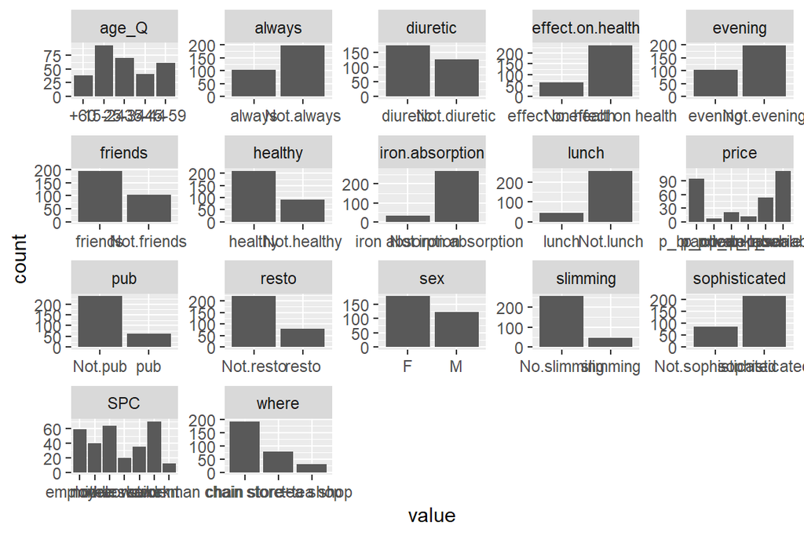

Task is to fit a multiple correspondence analysis to the data. Results are below. Selecting the columns at random doesn’t make much sense.

```r
mca <- MCA(tea1, graph = FALSE)
```

```r
summary(mca)
```

```
##
## Call:
## MCA(X = tea1, graph = FALSE)
##
##
## Eigenvalues
##                        Dim.1   Dim.2   Dim.3   Dim.4   Dim.5   Dim.6
## Variance               0.134   0.115   0.113   0.093   0.088   0.081
## % of var.              7.575   6.539   6.393   5.250   4.991   4.612
## Cumulative % of var.   7.575  14.115  20.508  25.758  30.748  35.360
##                        Dim.7   Dim.8   Dim.9  Dim.10  Dim.11  Dim.12
## Variance               0.078   0.077   0.072   0.068   0.065   0.062
## % of var.              4.413   4.361   4.105   3.861   3.671   3.526
## Cumulative % of var.  39.773  44.134  48.239  52.100  55.771  59.297
##                       Dim.13  Dim.14  Dim.15  Dim.16  Dim.17  Dim.18
## Variance               0.061   0.057   0.057   0.054   0.051   0.048
## % of var.              3.437   3.249   3.205   3.081   2.897   2.712
## Cumulative % of var.  62.734  65.982  69.187  72.268  75.165  77.877
##                       Dim.19  Dim.20  Dim.21  Dim.22  Dim.23  Dim.24
## Variance               0.046   0.043   0.043   0.040   0.038   0.038
## % of var.              2.603   2.447   2.425   2.284   2.170   2.133
## Cumulative % of var.  80.480  82.927  85.352  87.636  89.806  91.939
##                       Dim.25  Dim.26  Dim.27  Dim.28  Dim.29  Dim.30
## Variance               0.032   0.030   0.028   0.020   0.018   0.015
## % of var.              1.806   1.684   1.565   1.136   1.002   0.868
## Cumulative % of var.  93.745  95.429  96.994  98.130  99.132 100.000
##
## Individuals (the 10 first)
##                        Dim.1    ctr   cos2    Dim.2    ctr   cos2    Dim.3
## 1                   |  0.277  0.192  0.027 | -0.662  1.266  0.156 | -0.063
## 2                   |  0.216  0.116  0.037 | -0.181  0.095  0.026 | -0.282
## 3                   | -0.142  0.050  0.011 | -0.070  0.014  0.003 |  0.243
## 4                   | -0.216  0.116  0.050 | -0.233  0.157  0.059 | -0.248
## 5                   | -0.029  0.002  0.001 | -0.402  0.467  0.113 | -0.055
## 6                   | -0.306  0.234  0.054 | -0.377  0.411  0.082 | -0.499
## 7                   |  0.159  0.063  0.017 | -0.294  0.249  0.059 |  0.222
## 8                   |  0.140  0.049  0.014 | -0.296  0.254  0.063 | -0.002
## 9                   |  0.578  0.834  0.181 | -0.323  0.301  0.056 |  0.373
## 10                  |  0.447  0.497  0.105 | -0.174  0.087  0.016 |  0.368
##                        ctr   cos2
```

[output cut: 32 more lines]

```
## employee            -3.797 | -0.458  2.146  0.051 -3.914 |
## middle              -4.119 |  0.265  0.487  0.011  1.796 |
##
## Categorical variables (eta2)
##                       Dim.1 Dim.2 Dim.3
## slimming            | 0.013 0.087 0.065 |
## effect.on.health    | 0.033 0.006 0.003 |
## friends             | 0.108 0.057 0.160 |
## diuretic            | 0.009 0.089 0.019 |
## SPC                 | 0.586 0.511 0.211 |
## where               | 0.228 0.175 0.309 |
## age_Q               | 0.598 0.501 0.151 |
## lunch               | 0.051 0.103 0.065 |
## sex                 | 0.084 0.140 0.042 |
## pub                 | 0.105 0.069 0.054 |
```

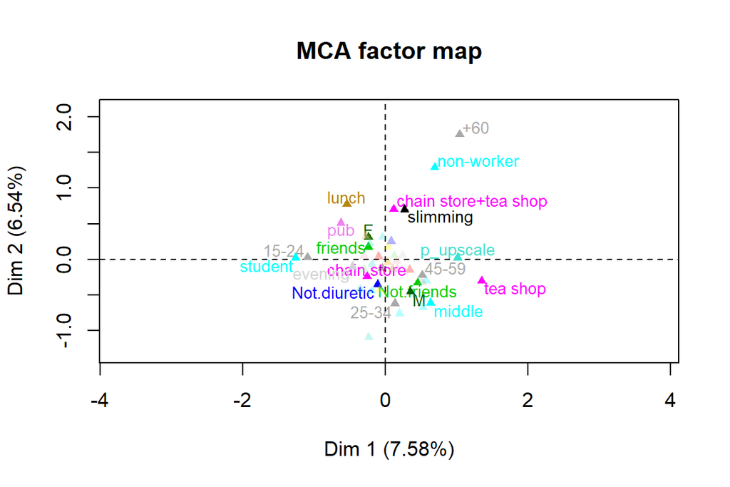

```r
plot(mca, invisible=c("ind"), habillage="quali", cex=0.8, selectMod="contrib 20")
```

# Clustering and classification

Boston dataset, that is used in this exercise, is available in the package MASS. Dataset has 506 rows and 14 variables The dataset has information on the factors that effect housing prices in the suburbs of Bosto, that is: crime rate, business, nature, pollution, average size of housing in the are and so on.

Summary and graphical overview of the data is in the graph below.

There are some clear and interesting linear (or polynomial) relationships in the data, for example houses that have more rooms [rm] tend to be more expensive in the median value [medv].

Also houses tend be more expensive if the proportion of population in the lower status [lstat] is low. Interestingly the proportion of the population goes up as the pollution [nox] goes up but median value of the housing goes down with high pollution.

Boston in the 1970s was clearly not one of the towns where the inner city is the most expensive neighbourhood.

```r
print(summary(Boston))
```

```
##       crim                zn             indus            chas
##  Min.   : 0.00632   Min.   :  0.00   Min.   : 0.46   Min.   :0.00000
##  1st Qu.: 0.08204   1st Qu.:  0.00   1st Qu.: 5.19   1st Qu.:0.00000
##  Median : 0.25651   Median :  0.00   Median : 9.69   Median :0.00000
##  Mean   : 3.61352   Mean   : 11.36   Mean   :11.14   Mean   :0.06917
##  3rd Qu.: 3.67708   3rd Qu.: 12.50   3rd Qu.:18.10   3rd Qu.:0.00000
##  Max.   :88.97620   Max.   :100.00   Max.   :27.74   Max.   :1.00000
##       nox               rm             age              dis
##  Min.   :0.3850   Min.   :3.561   Min.   :  2.90   Min.   : 1.130
##  1st Qu.:0.4490   1st Qu.:5.886   1st Qu.: 45.02   1st Qu.: 2.100
##  Median :0.5380   Median :6.208   Median : 77.50   Median : 3.207
##  Mean   :0.5547   Mean   :6.285   Mean   : 68.57   Mean   : 3.795
##  3rd Qu.:0.6240   3rd Qu.:6.623   3rd Qu.: 94.08   3rd Qu.: 5.188
##  Max.   :0.8710   Max.   :8.780   Max.   :100.00   Max.   :12.127
##       rad              tax           ptratio          black
##  Min.   : 1.000   Min.   :187.0   Min.   :12.60   Min.   :  0.32
##  1st Qu.: 4.000   1st Qu.:279.0   1st Qu.:17.40   1st Qu.:375.38
##  Median : 5.000   Median :330.0   Median :19.05   Median :391.44
##  Mean   : 9.549   Mean   :408.2   Mean   :18.46   Mean   :356.67
##  3rd Qu.:24.000   3rd Qu.:666.0   3rd Qu.:20.20   3rd Qu.:396.23
##  Max.   :24.000   Max.   :711.0   Max.   :22.00   Max.   :396.90
##      lstat            medv
##  Min.   : 1.73   Min.   : 5.00
##  1st Qu.: 6.95   1st Qu.:17.02
##  Median :11.36   Median :21.20
##  Mean   :12.65   Mean   :22.53
##  3rd Qu.:16.95   3rd Qu.:25.00
##  Max.   :37.97   Max.   :50.00
```

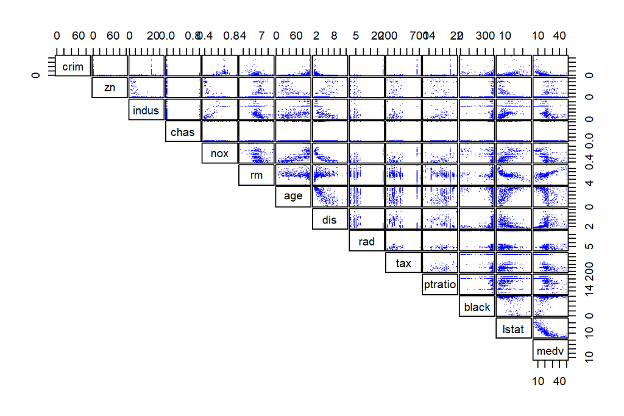

```r
pairs(Boston, lower.panel = NULL, col=alpha('blue', 0.8), gap=0.1, pch='.')
```

Standardizing a variable means that the variable is scaled to have a mean of 0 and standard deviation of 1. Boston dataset contains only numerical variables, so every column can be standardized. Here is a summary of the data after it has been standardized. Now every variable is on the same scale and can be compared to other variables more easily.

```
##       crim                 zn               indus
##  Min.   :-0.419367   Min.   :-0.48724   Min.   :-1.5563
##  1st Qu.:-0.410563   1st Qu.:-0.48724   1st Qu.:-0.8668
##  Median :-0.390280   Median :-0.48724   Median :-0.2109
##  Mean   : 0.000000   Mean   : 0.00000   Mean   : 0.0000
##  3rd Qu.: 0.007389   3rd Qu.: 0.04872   3rd Qu.: 1.0150
##  Max.   : 9.924110   Max.   : 3.80047   Max.   : 2.4202
##       chas              nox                rm               age
##  Min.   :-0.2723   Min.   :-1.4644   Min.   :-3.8764   Min.   :-2.3331
##  1st Qu.:-0.2723   1st Qu.:-0.9121   1st Qu.:-0.5681   1st Qu.:-0.8366
##  Median :-0.2723   Median :-0.1441   Median :-0.1084   Median : 0.3171
##  Mean   : 0.0000   Mean   : 0.0000   Mean   : 0.0000   Mean   : 0.0000
##  3rd Qu.:-0.2723   3rd Qu.: 0.5981   3rd Qu.: 0.4823   3rd Qu.: 0.9059
##  Max.   : 3.6648   Max.   : 2.7296   Max.   : 3.5515   Max.   : 1.1164
##       dis               rad               tax             ptratio
##  Min.   :-1.2658   Min.   :-0.9819   Min.   :-1.3127   Min.   :-2.7047
##  1st Qu.:-0.8049   1st Qu.:-0.6373   1st Qu.:-0.7668   1st Qu.:-0.4876
##  Median :-0.2790   Median :-0.5225   Median :-0.4642   Median : 0.2746
##  Mean   : 0.0000   Mean   : 0.0000   Mean   : 0.0000   Mean   : 0.0000
##  3rd Qu.: 0.6617   3rd Qu.: 1.6596   3rd Qu.: 1.5294   3rd Qu.: 0.8058
##  Max.   : 3.9566   Max.   : 1.6596   Max.   : 1.7964   Max.   : 1.6372
##      black             lstat              medv
##  Min.   :-3.9033   Min.   :-1.5296   Min.   :-1.9063
##  1st Qu.: 0.2049   1st Qu.:-0.7986   1st Qu.:-0.5989
##  Median : 0.3808   Median :-0.1811   Median :-0.1449
##  Mean   : 0.0000   Mean   : 0.0000   Mean   : 0.0000
##  3rd Qu.: 0.4332   3rd Qu.: 0.6024   3rd Qu.: 0.2683
##  Max.   : 0.4406   Max.   : 3.5453   Max.   : 2.9865
```

## Building a categorized dependent variable

For linear discriminant analysis the dependent variable need to be categorical. Below is first a histogram of the original continuous variable and then propensity table of the dependent variable when it is categorized according to quantile function.

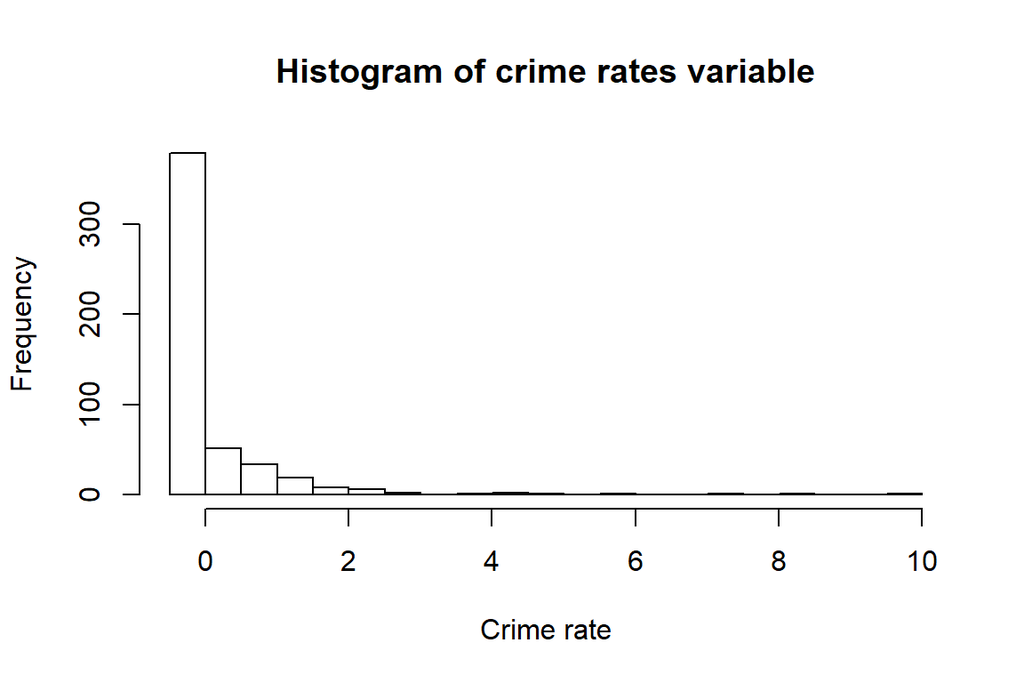

```
## [1] "Breaks are in points: "
```

```
##           0%          25%          50%          75%         100%
## -0.419366929 -0.410563278 -0.390280295  0.007389247  9.924109610
```

```
## [1] "Crime as categorized variable (%): "
```

```
## crime
##       low   med_low  med_high      high
## 0.2509881 0.2490119 0.2490119 0.2509881
```

## Linear discriminant analysis

The data is divided into train (80% of the rows) and test datasets.

Linear discriminanat analysis (LDA) is first fitted to the train dataset and the results are then tested with the second dataset. LDA assumes that each variable has the same variance and that variables are normally distributed (on condition of the classes). The former was achieved by standardizing the variables the latter is just assumed here.

Summary of the fitted model and corresponding plot are shown below. The arrow that didn’t fit into the plot corresponds to the variable indicating accessibility to radial highways [rad]. The length and the direction of the arrow indicates the impact of the variable - so here access to radial highways is strongly associated with higher crime rates.

```
## Call:
## lda(crim ~ ., data = train)
##
## Prior probabilities of groups:
##       low   med_low  med_high      high
## 0.2524752 0.2500000 0.2500000 0.2475248
##
## Group means:
##                   zn      indus        chas        nox          rm
## low       1.09753241 -0.9838878 -0.07933396 -0.9084204  0.51162067
## med_low  -0.08563849 -0.2831229 -0.15538550 -0.5518196 -0.13029184
## med_high -0.40063686  0.1458017  0.23442641  0.3041616  0.08622539
## high     -0.48724019  1.0171519 -0.03610305  1.0515825 -0.39191242
##                 age        dis        rad        tax     ptratio
## low      -0.9521647  0.9172964 -0.6812431 -0.7554739 -0.50159496
## med_low  -0.3977668  0.3919987 -0.5475005 -0.4777249 -0.07595779
## med_high  0.3549851 -0.3270321 -0.3962667 -0.3174053 -0.21818807
## high      0.8186512 -0.8611488  1.6377820  1.5138081  0.78037363
##               black      lstat         medv
## low       0.3839551 -0.8194564  0.612142553
## med_low   0.3249402 -0.1524295  0.009028414
## med_high  0.1579284  0.0134775  0.173845683
## high     -0.6951172  0.9064810 -0.691718422
##
## Coefficients of linear discriminants:
##                  LD1         LD2        LD3
## zn       0.113061890  0.89677827 -0.8034932
## indus    0.033423745 -0.43249357  0.3827079
## chas    -0.013314438 -0.02507795 -0.1627062
## nox      0.419860672 -0.43610322 -1.3846232
## rm       0.043643119 -0.04172437 -0.2210099
## age      0.225958758 -0.24924518 -0.1824162
## dis     -0.113560166 -0.36913069  0.3307003
## rad      3.108846605  0.96498489  0.0186388
## tax     -0.001446095 -0.06631976  0.6341279
## ptratio  0.130543034  0.02705679 -0.2881569
## black   -0.145656252  0.02785503  0.1201647
## lstat    0.200291294 -0.28258116  0.2846409
## medv     0.063484600 -0.38137447 -0.1709950
##
## Proportion of trace:
##    LD1    LD2    LD3
## 0.9464 0.0404 0.0132
```

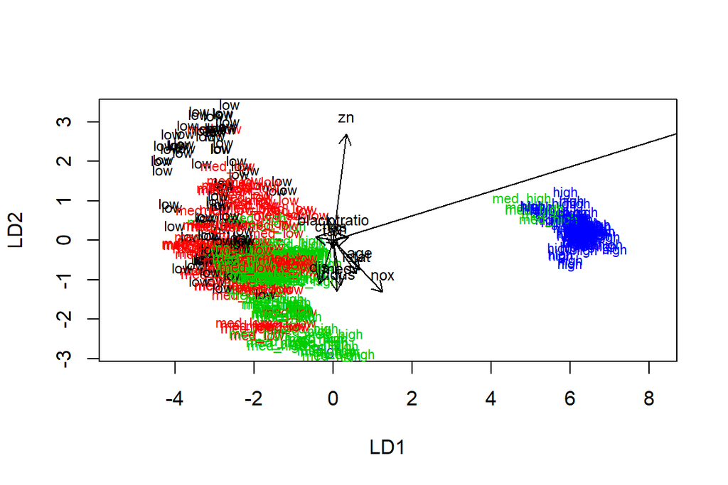

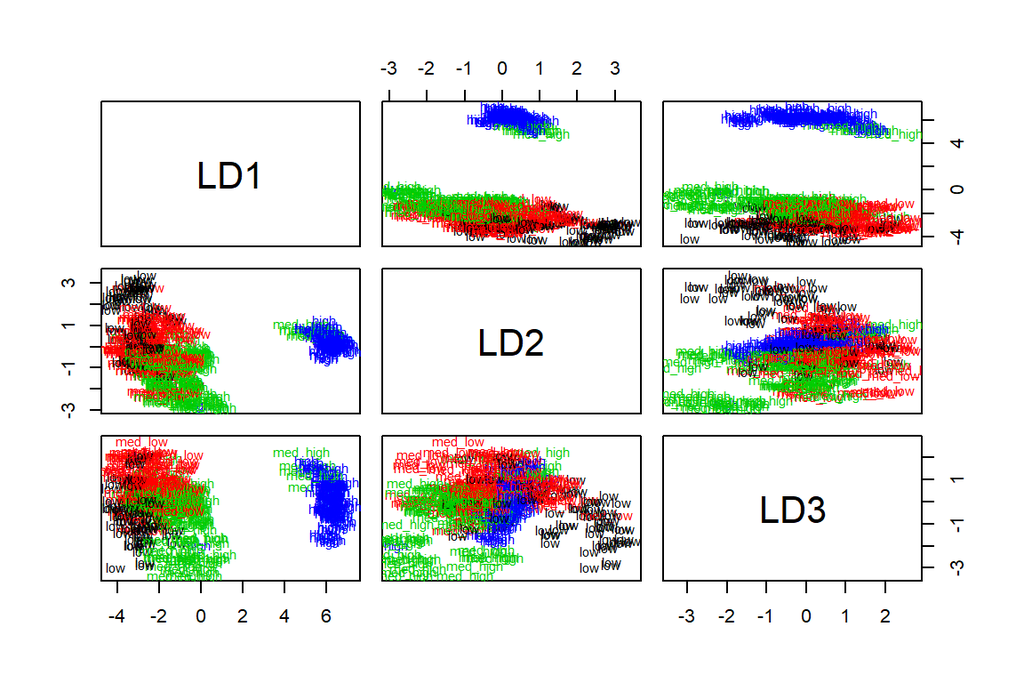

And indeed the high crime rate group is clearly recognizable from the plots (above), where LD1 is on one of the axes. When LD2 and LD3 are plotted on the same plot, all categories are more mixed together and the groups are not as easily identidiable.

When you look at the values, the heaviest load in LD1 is rad.

## Testing the model

```r
crimeTest=test$crim
test <- dplyr::select(test, -crim)
lda.pred <- predict(bostonFit, newdata = test)

table(correct = crimeTest, predicted = lda.pred$class)
```

```
##           predicted
## correct    low med_low med_high high
##   low       10      11        4    0
##   med_low    4      17        4    0
##   med_high   1       3       20    1
##   high       0       0        0   27
```

```r
# cross tabulate the results
table(correct = crimeTest, predicted = lda.pred$class)%>%prop.table(1)*100
```

```
##           predicted
## correct    low med_low med_high high
##   low       40      44       16    0
##   med_low   16      68       16    0
##   med_high   4      12       80    4
##   high       0       0        0  100
```

## K-means clustering

Last task of the week is to fit k-means clustering to the standardized Boston dataset. Line plot below visualizes the clusters. Since there’s a clear drop between 1 cluster and 2 clusters I decide to go the simple way: my choice of optimal number of clusters is 2.

Of course you could go with three or even four might be interesting, but the drop in the sum of squares is not so great then.

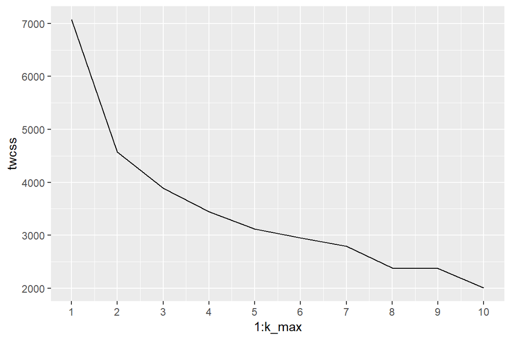

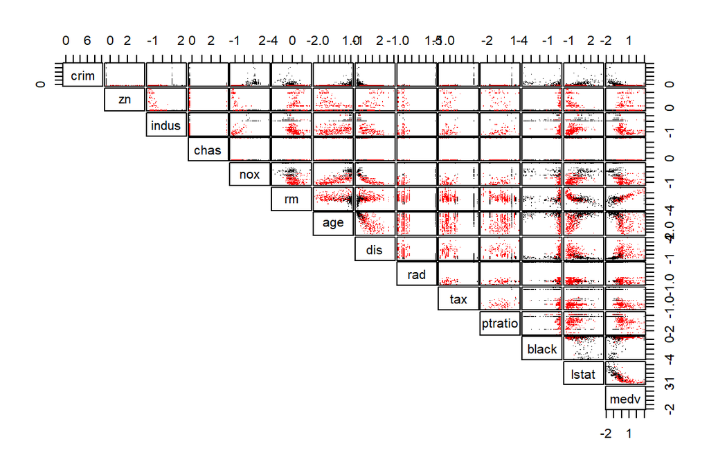